# Желтое такси нью-йоркских улиц... (2 часть)

*О-о-о-оооо, притормози, притормози...* **М.Боярский**

Итак, подключим библиотеки и загрузим агрегированные данные за май 2016 из предыдущей недели:

```python
import pandas as pd
import numpy as np
```

```python
data = pd.read_csv('05_2016.csv',  index_col=[0], parse_dates=[0])
data.head()
```

| row_0 | 0 | 1 | 2 | 3 | 4 | 5 | 6 | 7 | 8 | 9 | ... | 2490 | 2491 | 2492 | 2493 | 2494 | 2495 | 2496 | 2497 | 2498 | 2499 |
| --- | --- | --- | --- | --- | --- | --- | --- | --- | --- | --- | --- | --- | --- | --- | --- | --- | --- | --- | --- | --- | --- |
| 2016-05-01 00:00:00 | 0 | 0 | 0 | 0 | 0 | 0 | 0 | 0 | 0 | 0 | ... | 0 | 0 | 0 | 0 | 0 | 0 | 0 | 0 | 0 | 0 |
| 2016-05-01 01:00:00 | 0 | 0 | 0 | 0 | 0 | 0 | 0 | 0 | 0 | 0 | ... | 0 | 0 | 0 | 0 | 0 | 0 | 0 | 0 | 0 | 0 |
| 2016-05-01 02:00:00 | 0 | 0 | 0 | 0 | 0 | 0 | 0 | 0 | 0 | 0 | ... | 0 | 0 | 0 | 0 | 0 | 0 | 0 | 0 | 0 | 0 |
| 2016-05-01 03:00:00 | 0 | 0 | 0 | 0 | 0 | 0 | 0 | 0 | 0 | 0 | ... | 0 | 0 | 0 | 0 | 0 | 0 | 0 | 0 | 0 | 0 |
| 2016-05-01 04:00:00 | 0 | 0 | 0 | 0 | 0 | 0 | 0 | 0 | 0 | 0 | ... | 0 | 0 | 0 | 0 | 0 | 0 | 0 | 0 | 0 | 0 |

5 rows × 2500 columns

Просуммируем общее количество поездок такси *regions_trips_sum* из каждой зоны и посчитаем количество ячеек, из которых в мае не было совершено ни одной поездки:

```python
regions_trips_sum = []
for column in data:
    regions_trips_sum.append(data[column].sum())
```

```python
regions_trips_sum = np.array(regions_trips_sum)
print ("Zero trips regions count  = %i" %regions_trips_sum[regions_trips_sum == 0].size)
```

```
Zero trips regions count  = 1283
```

**В целях экономии времени, использованы уже готовые данные по итогам первой недели. Заново сырой файл с данными о поездках не загружается!**

Загрузим предоставленные координаты ячеек, а также по итогам процедуры из первой недели *binned_statistic_2d* возьмем массивы координат краев ячеек. Это и будет наша сетка.

```python
regions_data = pd.read_csv('regions.csv', delimiter=';')
regions_data.head(10)
```

|  | region | west | east | south | north |
| --- | --- | --- | --- | --- | --- |
| 0 | 1 | -74.25559 | -74.244478 | 40.496120 | 40.504508 |
| 1 | 2 | -74.25559 | -74.244478 | 40.504508 | 40.512896 |
| 2 | 3 | -74.25559 | -74.244478 | 40.512896 | 40.521285 |
| 3 | 4 | -74.25559 | -74.244478 | 40.521285 | 40.529673 |
| 4 | 5 | -74.25559 | -74.244478 | 40.529673 | 40.538061 |
| 5 | 6 | -74.25559 | -74.244478 | 40.538061 | 40.546449 |
| 6 | 7 | -74.25559 | -74.244478 | 40.546449 | 40.554837 |
| 7 | 8 | -74.25559 | -74.244478 | 40.554837 | 40.563226 |
| 8 | 9 | -74.25559 | -74.244478 | 40.563226 | 40.571614 |
| 9 | 10 | -74.25559 | -74.244478 | 40.571614 | 40.580002 |

```python
x_edge=np.array([-74.25559  , -74.2444784, -74.2333668, -74.2222552, -74.2111436,
       -74.200032 , -74.1889204, -74.1778088, -74.1666972, -74.1555856,
       -74.144474 , -74.1333624, -74.1222508, -74.1111392, -74.1000276,
       -74.088916 , -74.0778044, -74.0666928, -74.0555812, -74.0444696,
       -74.033358 , -74.0222464, -74.0111348, -74.0000232, -73.9889116,
       -73.9778   , -73.9666884, -73.9555768, -73.9444652, -73.9333536,
       -73.922242 , -73.9111304, -73.9000188, -73.8889072, -73.8777956,
       -73.866684 , -73.8555724, -73.8444608, -73.8333492, -73.8222376,
       -73.811126 , -73.8000144, -73.7889028, -73.7777912, -73.7666796,
       -73.755568 , -73.7444564, -73.7333448, -73.7222332, -73.7111216,
       -73.70001  ])
y_edge=np.array([ 40.49612  ,  40.5045082,  40.5128964,  40.5212846,  40.5296728,
        40.538061 ,  40.5464492,  40.5548374,  40.5632256,  40.5716138,
        40.580002 ,  40.5883902,  40.5967784,  40.6051666,  40.6135548,
        40.621943 ,  40.6303312,  40.6387194,  40.6471076,  40.6554958,
        40.663884 ,  40.6722722,  40.6806604,  40.6890486,  40.6974368,
        40.705825 ,  40.7142132,  40.7226014,  40.7309896,  40.7393778,
        40.747766 ,  40.7561542,  40.7645424,  40.7729306,  40.7813188,
        40.789707 ,  40.7980952,  40.8064834,  40.8148716,  40.8232598,
        40.831648 ,  40.8400362,  40.8484244,  40.8568126,  40.8652008,
        40.873589 ,  40.8819772,  40.8903654,  40.8987536,  40.9071418,
        40.91553  ])
```

### Статическая карта

Подключим библиотеки для визуализации. Для статической карты используем *Basemap*:

```python
%matplotlib inline
import numpy as np
import matplotlib.pyplot as plt
from mpl_toolkits.basemap import Basemap
```

Создадим сетку для карты:

```python
lat = y_edge
lon = x_edge
lon, lat = np.meshgrid(lon, lat)
```

Теперь разобъем массив количества поездок по регионам на участки (50 х 50) для цветовой шкалы:

```python
chunks = [regions_trips_sum[x:x+50] for x in xrange(0, len(regions_trips_sum), 50)]
chunks = np.array(chunks)
chunks
```

```
array([[0, 0, 0, ..., 0, 0, 5],
       [0, 0, 0, ..., 0, 0, 0],
       [0, 0, 0, ..., 0, 0, 0],
       ...,
       [0, 0, 0, ..., 0, 0, 0],
       [0, 0, 0, ..., 0, 0, 0],
       [0, 0, 0, ..., 0, 0, 0]], dtype=int64)
```

Находим координаты Эмпайер Стейт Билдинга:

```python
ESB_longitude = -73.985428
ESB_latitude = 40.748817
```

Дальше дело за Basemap. Выбираем цилиндрическую проекцию в аргументах, обозначем координаты углов нашей сетки Нью-Йорка. Отрисовываем береговые линии, границы, реки.. Далее для метки вбивем координаты Эмпайер Стейт Билдинга. После этого, на основании разбиения на участки по сумме поездок формируем цветовую карту:

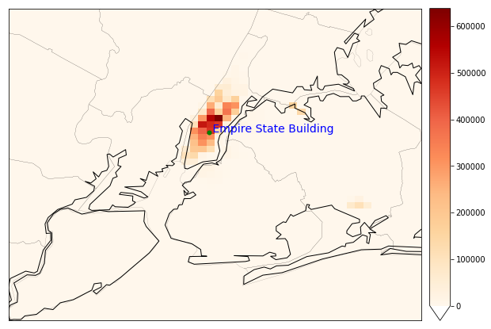

```python
fig = plt.figure(figsize=(10, 10), edgecolor='w')
m = Basemap(projection='cyl', resolution='h',
            llcrnrlat=40.49612, urcrnrlat=40.91553,
            llcrnrlon=-74.25559, urcrnrlon=-73.70001)

#m.drawmapboundary(fill_color="#DDEEFF")
m.drawcoastlines()
m.drawcounties()
m.drawrivers()

x, y = m(ESB_longitude, ESB_latitude)
plt.plot(x, y, 'ok', markersize=5, color='green' )
plt.text(x, y, ' Empire State Building', fontsize=14, color='blue')

my_cmap = plt.get_cmap('OrRd')
my_cmap.set_under('white')
cs = m.pcolormesh(lon, lat, chunks.transpose(), cmap=my_cmap)
m.colorbar(cs, extend = 'min')
plt.show()
```

### Динамической карта

Подготовим данные по всем пунктам и вставим их на финальной карте в конце ноутбука.  
Для динамической карты я использовал *folium*.

```python
import folium
from folium import IFrame
import base64
```

Создадим массив среднего количество за месяц поездок такси в час из каждой зоны *regions_trips_mean*:

```python
regions_trips_mean = []
for column in data:
    regions_trips_mean.append(data[column].sum()/(24.0*31.0))
regions_trips_mean = np.array(regions_trips_mean)
```

Далее сформируем словарь среднего количества поездок по ключам - id зон. Это необходимо для цветовой карты.

```python
colors_dict = pd.DataFrame(regions_trips_mean)
colors_dict['id'] = regions_data.region
colors_dict = colors_dict.set_index('id')[0]

colors_dict.head()
```

```
id
1    0.0
2    0.0
3    0.0
4    0.0
5    0.0
Name: 0, dtype: float64
```

Далее буду описывать коротко. Для folium необходимы данные в формате GeoJSON. Для него нужны координаты углов каждой зоны. Формируем их исходя из данного нам датасета regions.csv. 5 точек, потому что в конце нужно вернуться в точку, с которой начинали.

```python
regions_square_coords = []
for i in range(0,regions_data.shape[0],1):
    temp = [[(regions_data.iloc[i].west,regions_data.iloc[i].south),(regions_data.iloc[i].west,regions_data.iloc[i].north),(regions_data.iloc[i].east,regions_data.iloc[i].north),(regions_data.iloc[i].east,regions_data.iloc[i].south),(regions_data.iloc[i].west,regions_data.iloc[i].south)]]
    regions_square_coords.append(temp)
regions_square_coords[0]
```

```
[[(-74.255589999999998, 40.496119999999998),
  (-74.255589999999998, 40.504508200000004),
  (-74.244478400000006, 40.504508200000004),
  (-74.244478400000006, 40.496119999999998),
  (-74.255589999999998, 40.496119999999998)]]
```

Формируем GeoJSON, добавляя к координатам поле id для идентификации цвета данного сегмента.

```python
from geojson import Feature, Polygon, FeatureCollection
fk = []
for i in range(0,2500,1):
    my_feature = Feature(geometry=Polygon(regions_square_coords[i]), id = regions_data.iloc[i].region)
    fk.append(my_feature)
feature_collection = FeatureCollection(fk)
```

Сделаем и глянем на colormap:

```python
from branca.colormap import linear
import branca.colormap as cm

colormap = cm.LinearColormap(colors=['lime','red'], index=[regions_trips_mean.min()+5,regions_trips_mean.max() - regions_trips_mean.max()/3],vmin=regions_trips_mean.min()+5,vmax=regions_trips_mean.max())
```

```python
colormap
```

[figure not shown]

Найдем в Интернете координаты Статуи Свободы:

```python
SL_longitude = -74.044502
SL_latitude = 40.689247
```

Собственно говоря все. Создаем карту через folium, укзываем все параметры, которые были созданы ранее. К параметрам отображения добавил условие "Если среднее количество поездок меньше 5, то не отображать (отображать прозрачным цветом)":

```python
lon, lat = -73.985901, 40.768040
zoom_start = 10
m = folium.Map(location=[lat, lon], tiles='Cartodb dark_matter', zoom_start=zoom_start)

folium.GeoJson(
    feature_collection,
    style_function=lambda feature: {
    'fillColor': '#AA000000' if colors_dict[feature['id']]< 5 else colormap(colors_dict[feature['id']]),
    'color': 'gray',
    'weight': 0.1,
    'dashArray': '3, 3'
    }
).add_to(m)


encoded = base64.b64encode(open('413.jpg', 'rb').read()).decode()

html = '<img src="data:…">  <b>Statue of Liberty</b> '.format
iframe = IFrame(html(encoded), width=300, height=150)
popup = folium.Popup(iframe, max_width=512)

marker = folium.features.Marker([SL_latitude, SL_longitude], popup=popup)
marker.add_to(m)
colormap.caption = 'Averege taxi orders per hour color scale'
colormap.add_to(m)



m
```

[interactive chart not shown]

```python
cells_less5 = colors_dict[colors_dict<5]
print ("Количество ячеек, в которых в среднем поездок меньше, чем 5: %i" %cells_less5.size)
print ("Количество ячеек, в которых в среднем поездок больше либо равно 5: %i" % (colors_dict.size - cells_less5.size))
```

```
Количество ячеек, в которых в среднем поездок меньше, чем 5: 2398
Количество ячеек, в которых в среднем поездок больше либо равно 5: 102
```

Про ячейки на карте. В целом каждая ячейка имеет место быть, кроме одной. Ее тяжело объяснить, но чисто формально можно - небольшой кусочек суши она все таки захватывает. + можно сделать поправку на погрешность приборов GPS